# Mars: A Small, Cold Desert World

Unit 2: Night Sky · the featured planet · Astronomy

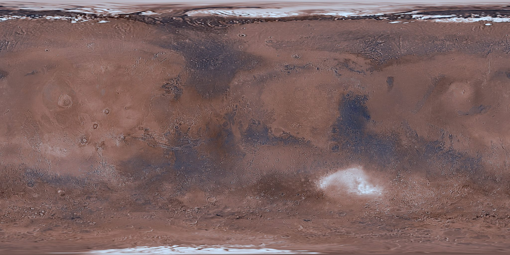

[figure not shown]

[interactive chart not shown]

Mars is a small, cold desert about half as wide as Earth. Its ground is red because the dust is rusted iron. It has the tallest volcano and the longest canyon of any planet, and white ice caps that grow and shrink with its seasons. Its air is so thin that water can't stay liquid on the ground for long.

Right now Mars rises after midnight. By **19 February 2027** it will be opposite the Sun, bright all night, and a telescope will show its north ice cap tipped toward us.

Today: learn to find 20 places on Mars, then find out what its ground, air and ice are made of.

Mars map: Viking (NASA/JPL/USGS). Open the Mars map app to spin it yourself.

## Mars at a glance

🌍

Size

about half as wide as Earth · radius 3,390 km

☀️

1.52 AU

Distance from the Sun

but it swings from 1.38 to 1.67 AU: a stretched orbit

🕑

24 h 40 min

One day (a "sol")

almost the same as ours

📅

687 days

One year

so each season lasts about twice as long as ours

🧭

25.2°

Tilt

close to Earth's 23.5°, so Mars has seasons too

⚖️

Gravity

a 150 lb student would weigh 57 lb

🌬️

< 1%

Air pressure, vs Earth

mostly carbon dioxide · you would need a pressure suit

🌡️

−74 °C

A typical night

afternoons at Curiosity's crater reach about −11 °C

## Six things to explore

Click a tile. You don’t need all six.

[figure not shown]

1

Where is it?

twenty places to know

[figure not shown]

2

The giants

the tallest volcano, the longest canyon

[figure not shown]

3

Old ground, young ground

Noachian, Hesperian, Amazonian

[figure not shown]

4

What the ground is made of

why Mars is red

[figure not shown]

5

Ice caps

water ice under dry ice

[figure not shown]

6

Air, cold and dust storms

how a storm covers a planet

← scroll the tiles →

### Where is it?

Like the Moon, Mars has names for its big features. **Mons** means mountain (here, a volcano), **planitia** a low plain, **planum** a high plain, **vallis** or **chasma** a valley or canyon, and **terra** old highland. The north of Mars is low and smooth; the south is high and covered in craters.

Find it: click where you think it is

[interactive chart not shown]

Measure: how far around Mars does Valles Marineris reach?

The canyon is about 4,000 km long. Mars's radius is 3,390 km. What fraction of the way around the planet is that?

**Reveal**

The distance around Mars is $2\pi R = 2\pi(3390\ \text{km}) = 21{,}300$ km. So $\dfrac{4000}{21{,}300} \approx 0.19$: $\boxed{\text{about } \tfrac{1}{5}}$ of the way around the planet. On Earth, a canyon that long would stretch from Portland to New York.

Practice all twenty in the Mars map quiz, and print a blank map to label.

### The giants

**Olympus Mons** is the tallest volcano in the solar system: its top is about **21 km** above the Mars "sea level" (the datum), and it is about 600 km across, roughly the size of Oregon. Nearby, three more giant volcanoes sit in a row on a huge bulge called **Tharsis**. East of them, **Valles Marineris** cracked open as the bulge pushed the crust up.

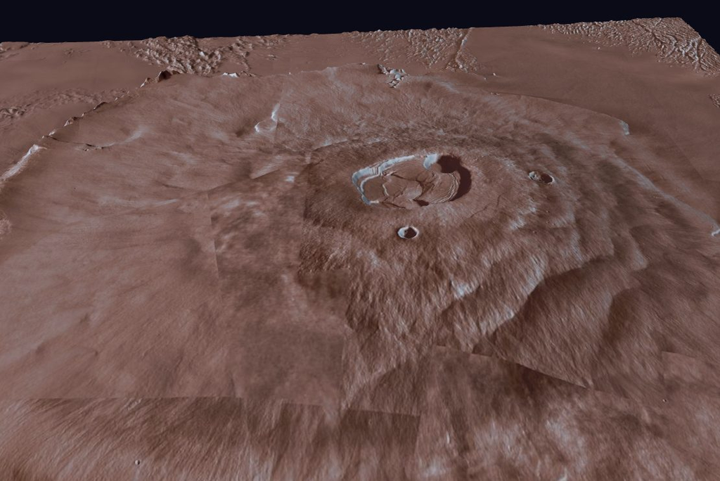

**Olympus Mons**, heights ×3. The summit crater (caldera) is about 80 km wide. Marsmap render: MOLA (NASA/GSFC), Viking (NASA/JPL/USGS)

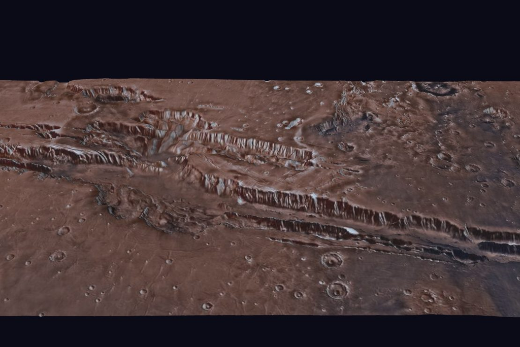

**Valles Marineris**, heights ×4. Up to 7 km deep. Marsmap render: MOLA (NASA/GSFC), Viking (NASA/JPL/USGS)

Guess first: how tall could a volcano grow on Mars?

Your guess**10 km**

[interactive chart not shown]

Everest is 8.8 km tall. Lock in a guess to see Olympus Mons at the same scale.

Why so tall? Gravity, in relative form

A mountain grows until its own weight crushes the rock at its base, so weaker gravity allows taller mountains. Use $g = \dfrac{GM}{R^2}$ in relative form with $M_{\rm M} = 6.4\times10^{23}$ kg, $M_\oplus = 6.0\times10^{24}$ kg and $\dfrac{R_\oplus}{R_{\rm M}} = 1.89$.

**Reveal**

$\dfrac{g_{\rm M}}{g_\oplus} = \dfrac{M_{\rm M}}{M_\oplus}\left(\dfrac{R_\oplus}{R_{\rm M}}\right)^2 = \dfrac{6.4\times10^{23}}{6.0\times10^{24}}\,(1.89)^2 = \boxed{0.38}$  
Height goes as $\dfrac{1}{g}$, so a Mars mountain can stand $\dfrac{1}{0.38} \approx 2.6$ times taller: $2.6 \times 8.8\ \text{km} \approx 23$ km. Olympus Mons is about 21 km. Mars also has no moving plates, so its crust sat over the same hot spot and the lava kept piling up in one place.

### Old ground, young ground

Geologists split Mars's history into three ages, each named after a place where that kind of ground is found:

**Noachian** (oldest, before about 3.7 billion years ago). Heavily cratered highlands. River valleys and lake beds from a wetter time.

**Hesperian** (about 3.7 to 3 billion years ago). Huge lava plains. Giant floods burst out of the ground and cut channels.

**Amazonian** (about the last 3 billion years). Cold and dry. Young lava, wind, dust and ice shape the ground.

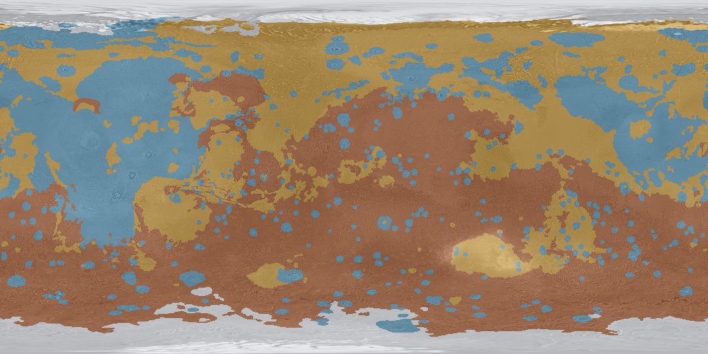

**Mars by age.** Brown Noachian, gold Hesperian, blue Amazonian, white polar ice. Tanaka et al. 2014, USGS SIM 3292

Count craters: which ground is older?

Both boxes are 600 km across. Craters pile up over time, so more craters means older ground. Guess first, then click each crater you can see to count it.

Older?

[interactive chart not shown]

Box A: 0 craters

[interactive chart not shown]

Box B: 0 craters

### What the ground is made of

Most of Mars is dark volcanic rock called **basalt**, the same kind of rock as Hawaiʻi. A thin coat of fine dust covers it. The dust is red because it holds **iron oxide**, which is rust. When Curiosity drilled into a rock, the powder came out grey: **the red is only skin deep.**

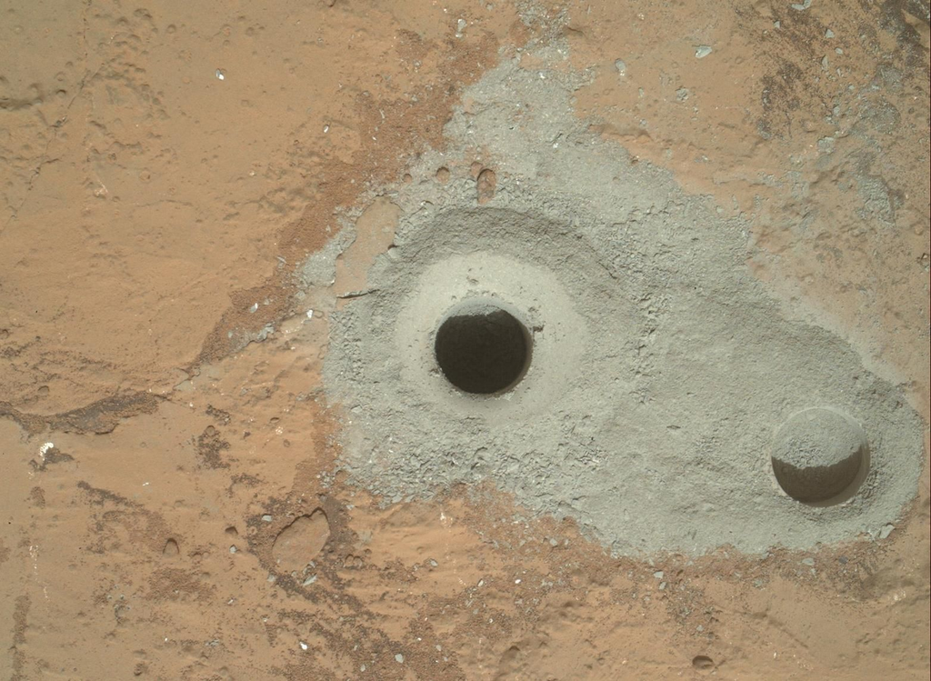

**Curiosity's first drill hole** (2013), about 1.6 cm wide. Grey rock under a red skin. NASA/JPL-Caltech/MSSS

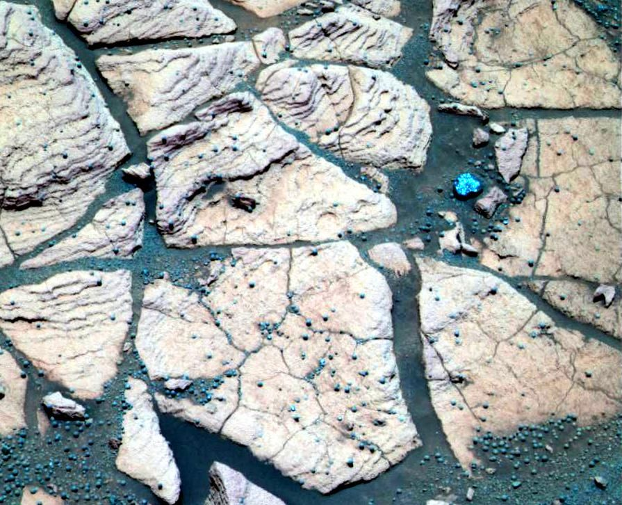

**"Blueberries."** BB-sized balls of the mineral hematite, found by Opportunity (false color). NASA/JPL/Cornell

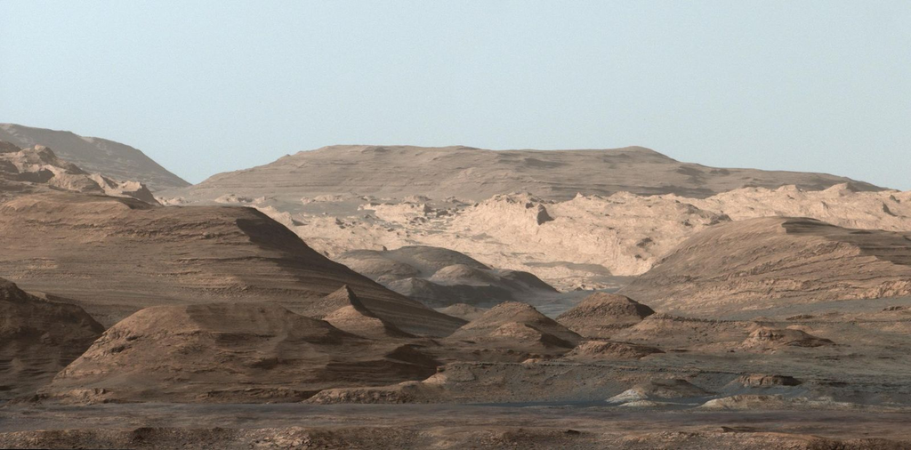

**Mount Sharp, from Curiosity.** Each layer is a page of Mars's history. NASA/JPL-Caltech/MSSS

The rovers look for minerals that only form in water. Tap each one to see what it tells us.

**Clay**Forms when water sits on rock for a long time. Found in Gale and Jezero craters: Mars once had lakes.

**Hematite "blueberries"**Grew inside wet rock as groundwater seeped through it, long ago.

**Sulfate salts**Left behind when salty water dried up, like a bathtub ring.

**Perchlorate salts**Found by the Phoenix lander in the soil. Toxic to people, so astronauts would have to keep the dust out.

### Ice caps

Both caps are mostly **water ice**, in layers up to about 3 km thick. In each hemisphere's winter, the air gets so cold that **carbon dioxide freezes** out of the air as frost: **dry ice**. This coat spreads far from the pole and then disappears in spring. The south cap keeps a thin layer of dry ice all year.

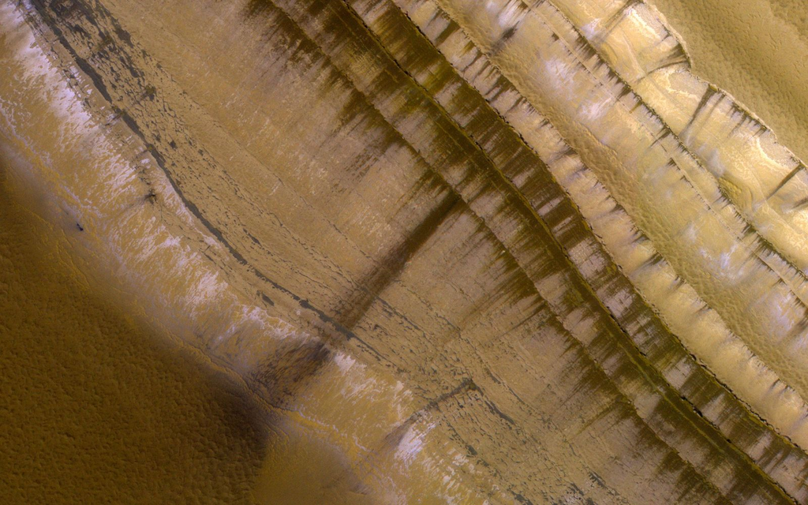

**Layers in the north cap.** Ice and dust laid down year after year, seen on a cliff at the cap's edge. NASA/JPL-Caltech/University of Arizona

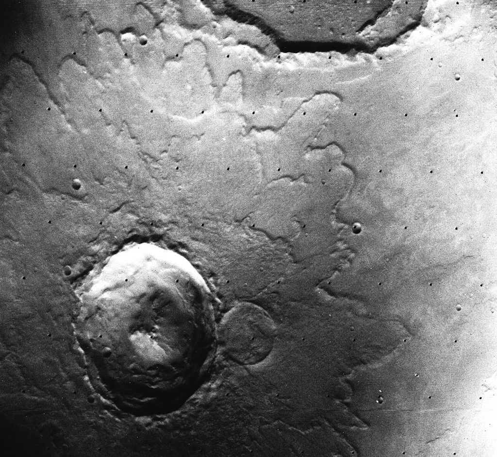

**Yuty, a "splat" crater.** The impact melted ice in the ground, so the debris flowed out like mud. Ice hides under much of Mars, not just at the poles. NASA/JPL (Viking 1 Orbiter)

Seasons on Mars: tilt moves the subsolar point

Guess first: which cap grows bigger in its winter?

[interactive chart not shown]

Mars's year

Measure: how high does the Sun get at the north pole?

Mars is tilted 25.2°, so at its northern summer solstice the subsolar point is at $25.2^\circ$N. Use $\theta_{\rm max} = 90 - |{\rm lat} - \delta|$ for the north pole (lat $= 90^\circ$).

**Reveal**

$\theta_{\rm max} = 90 - |90 - 25.2| = \boxed{25.2^\circ}$. Even in summer the Sun stays low, so the beam is spread thin and the cap never fully melts. At the winter solstice $\delta = -25.2^\circ$, and $90 - |90-(-25.2)| < 0$: the Sun never rises. That's the polar night, when the dry ice forms.

### Air, cold and dust storms

Mars's air is about **95% carbon dioxide** and very thin. Curiosity's weather station has measured the temperature every day since 2012: afternoons usually reach about **−11 °C**, and nights drop to about **−74 °C**. The thin air can't hold the day's heat.

Curiosity's daily high and low, over a Mars year

[interactive chart not shown]

Each dot is one day at Gale crater, 2012 to 2026. The season angle runs once around the Sun.

Measure: how thin is the air? Order of magnitude

Air pressure at Gale crater is about 800 Pa. At sea level on Earth it is about 101,000 Pa.

**Reveal**

$\dfrac{800}{101{,}000} \approx 0.008$, which is about $\dfrac{1}{100}$: $\boxed{\text{two orders of magnitude}}$ thinner. Water would boil and freeze at the same time, so it can't stay liquid on the ground for long.

**Dust devils** are spinning columns of warm, rising air that pick up dust, like the small ones over a dry field on Earth but much bigger. They leave dark tracks where they strip the bright dust away.

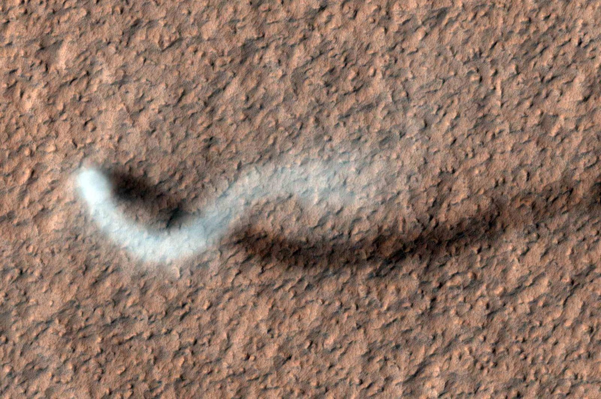

**A dust devil** seen from orbit, about 800 m tall; its long shadow shows its height. NASA/JPL-Caltech/University of Arizona

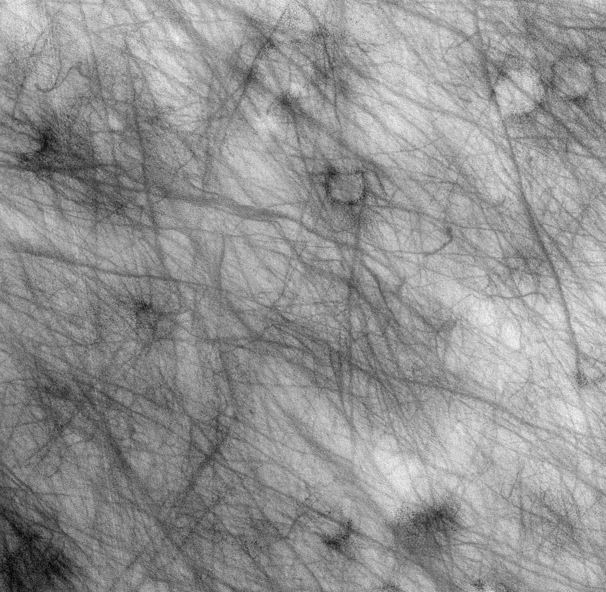

**Dust-devil tracks.** Dark scribbles where the bright dust was lifted off. NASA/JPL/University of Arizona

**How we think dust storms brew.** Sunlight warms the dusty air, the warm air rises, and the wind that rushes in lifts more dust. Dusty air soaks up even more sunlight, so a small storm can feed itself. Storms often start at the edge of a shrinking frost cap, where cold ice sits next to warm ground and makes strong winds: around the rim of Hellas, and in the north across Acidalia and Arabia. Most storms stay small. **Why a few grow to cover the whole planet is still an open question.**

The 2018 global dust storm: click where you think it started, then play

[interactive chart not shown]

Click the map first.

Real measurements of the dust in the air, every 4 Mars days (Montabone et al. 2020, LMD). The Opportunity rover was caught in this storm and never woke up.

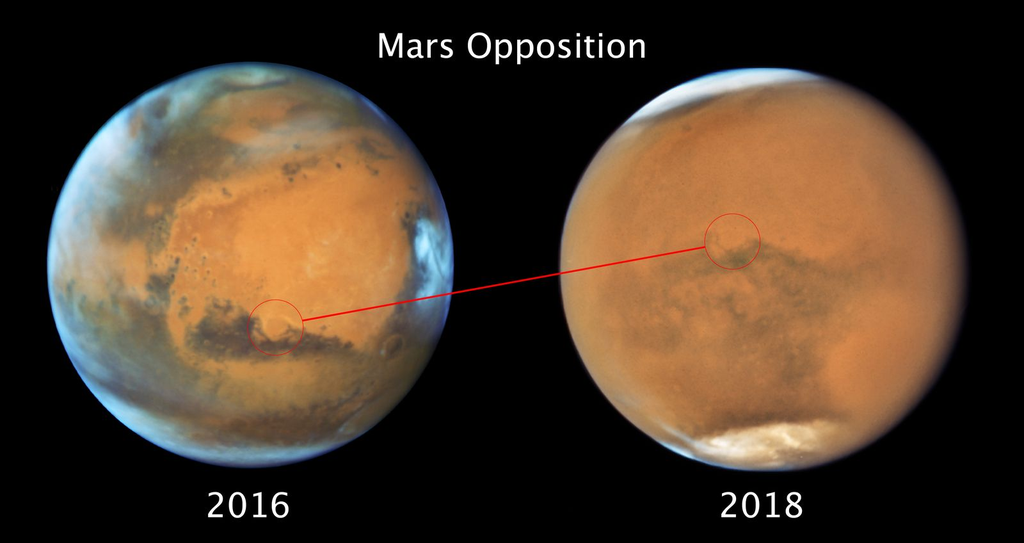

**Before and during.** Mars in 2016, and in July 2018 under the global storm. NASA, ESA, STScI

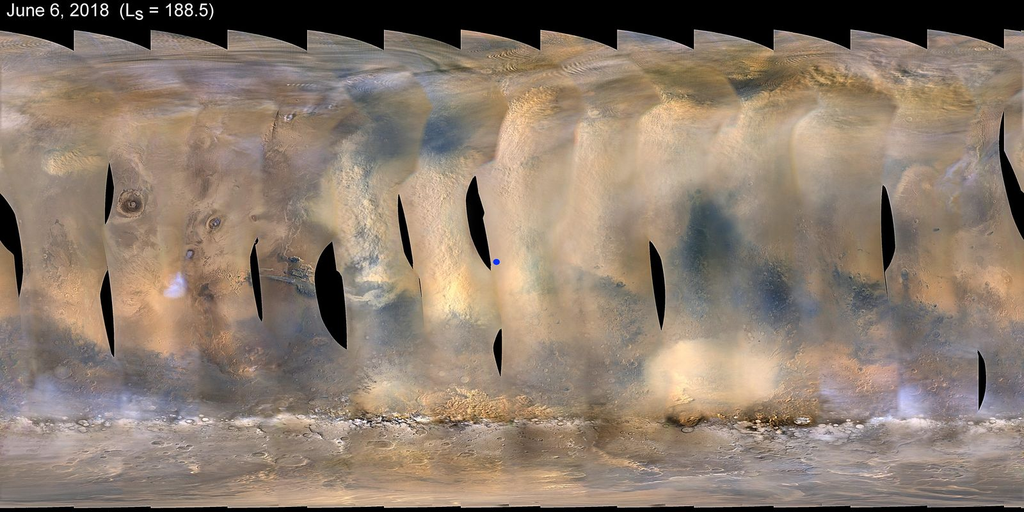

**The storm from orbit,** 6 June 2018: the dust (tan) is spreading over the planet. NASA/JPL-Caltech/MSSS

Tilt or eccentricity? Mars has both

Mars's distance from the Sun swings from 1.38 AU to 1.67 AU. Sunlight spreads out as $\dfrac{1}{d^2}$. How much stronger is the sunlight at the closest point?

**Reveal**

In relative form: $\dfrac{\text{sunlight}_{\rm close}}{\text{sunlight}_{\rm far}} = \left(\dfrac{1.67}{1.38}\right)^2 \approx \boxed{1.46}$, almost 50% stronger. The closest point comes near the start of southern summer, which is when the big dust storms grow. On Earth the change is only about 7%, so our seasons come from tilt alone.

## Name that place

[figure not shown]

Each picture looks straight down on the place. Pick what kind of place it is, then reveal the name. Keyboard: ← → to move, space to reveal. On a phone, swipe.

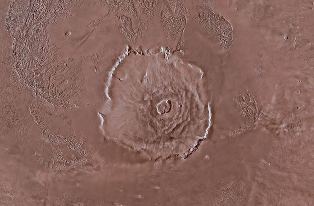

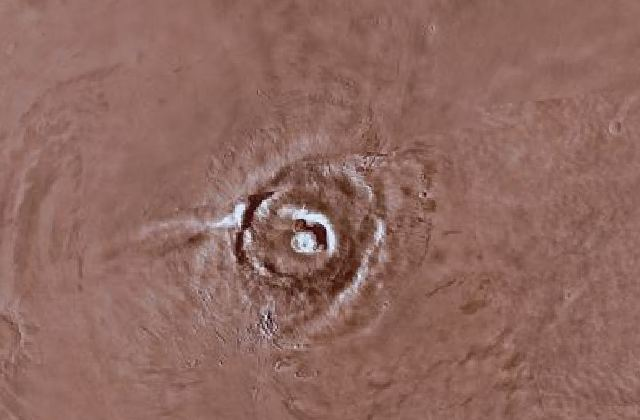

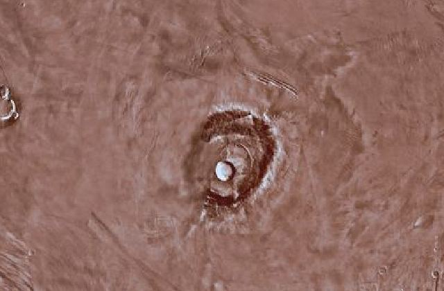

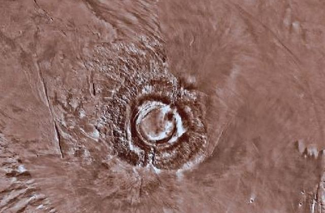

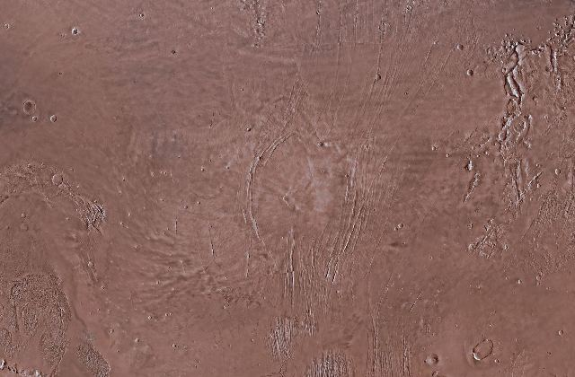

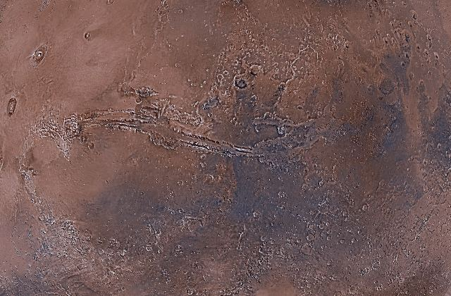

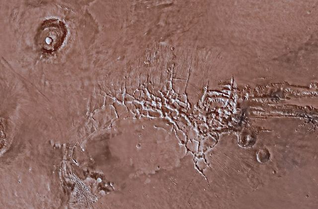

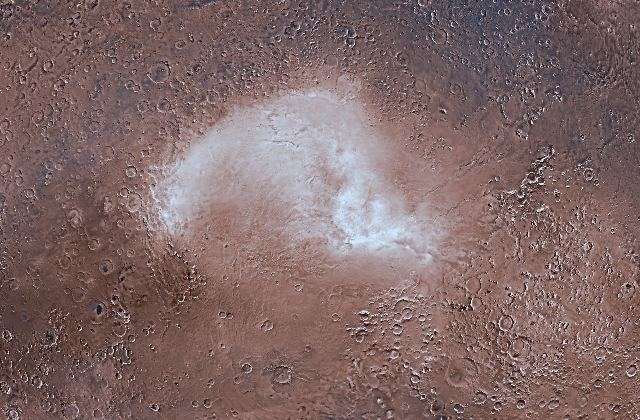

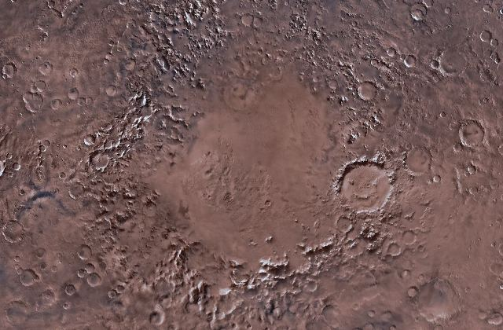

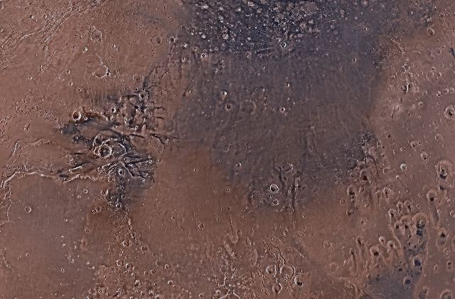

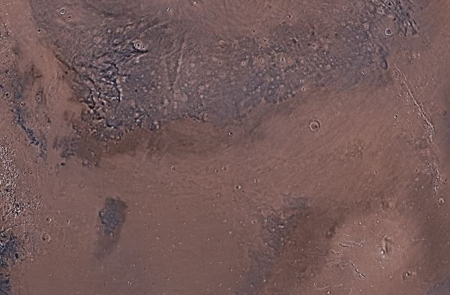

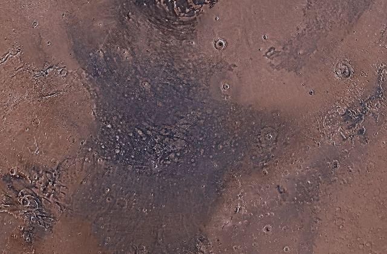

[8 more figures not shown]

**Sources and further reading**

Want to dig deeper? Each title links straight to the original.

**Where things are**

- [Mars Trek](https://trek.nasa.gov/mars/) (NASA): a zoomable map of the whole planet built from orbiter pictures and heights; fly anywhere and measure it.
- [Official names on Mars](https://planetarynames.wr.usgs.gov/Page/MARS/target) (USGS / IAU): every named crater, volcano and plain, with where it is and who it is named for.

**The giants**

- [Olympus Mons flyover](https://svs.gsfc.nasa.gov/1094) (NASA Scientific Visualization Studio): a movie flying over the tallest volcano, made from laser height measurements.
- [The Tharsis volcanoes and Valles Marineris](https://science.nasa.gov/photojournal/tharsis-volcanoes-and-valles-marineris-mars/) (NASA): one Viking view with the big volcanoes and the canyon together.

**Old ground, young ground**

- [Geologic Map of Mars](https://doi.org/10.3133/sim3292) (USGS): the map behind the page's "Mars by age" picture, with Noachian, Hesperian and Amazonian ground marked. Free to read. Tanaka et al. 2014, USGS Scientific Investigations Map 3292

**What the ground is made of**

- [Curiosity rover](https://science.nasa.gov/mission/msl-curiosity/) (NASA): drilling into the layers of Mount Sharp since 2012, with a weather station on board.
- [Spirit and Opportunity](https://science.nasa.gov/mission/mars-exploration-rovers-spirit-and-opportunity/) (NASA): the twin rovers; Opportunity found the hematite "blueberries."
- [Perseverance at the Jezero delta](https://science.nasa.gov/resource/perseverance-explores-the-jezero-crater-delta/) (NASA): a river once dropped mud and clay into a crater lake here.
- [Salts called perchlorates in the Phoenix soil](https://doi.org/10.1126/science.1172466): the lander's chemistry lab tested Martian dirt near the north pole. Summary free; full paper behind a paywall. Hecht et al. 2009, Science

**Ice caps**

- [The changing ice cap of Mars](https://science.nasa.gov/resource/the-changing-ice-cap-of-mars/) (NASA): the north cap shrinking and growing over a Mars year.
- [Dry ice on Mars](https://science.nasa.gov/resource/dry-ice-on-mars/) (NASA): how part of the air freezes onto the ground each winter and turns back to gas in spring.

**Air, cold and dust storms**

- [The 2018 global dust storm](https://svs.gsfc.nasa.gov/30983) (NASA Scientific Visualization Studio): the storm that wrapped the planet, seen from orbit.
- [Mapping the dust in the air, 2018](https://doi.org/10.1029/2019JE006111): the dust measurements the page plots, day by day through the global storm. Free copy on [arXiv](https://arxiv.org/abs/1907.08187). Montabone et al. 2020, Journal of Geophysical Research: Planets
- [Mars Climate Database](https://www-mars.lmd.jussieu.fr/) (LMD, Paris, with ESA and CNES): a computer model of Mars weather you can query for any place and season.

The page's map and 3D heights come from Viking pictures and MOLA laser heights (NASA/JPL/USGS, NASA/GSFC); its temperatures and pressures come from Curiosity's REMS weather station and the Viking landers; the frost map is a Mars Climate Database model.

**Image and data credits**

Pictures: Mars map, Viking MDIM 2.1 (NASA/JPL/USGS). 3D renders and heights from the Mars map app: MOLA (NASA/GSFC), Viking (NASA/JPL/USGS). Mars by age: Tanaka et al. 2014, USGS SIM 3292. Olympus Mons and Valles Marineris renders, overhead views and crater boxes: made from the same Viking and MOLA data. Hubble, Mars at opposition 2016 and 2018 (heic1814g): NASA, ESA, and STScI (CC BY 4.0). Dust Storm Covers Opportunity (PIA22329): NASA/JPL-Caltech/MSSS. The Serpent Dust Devil of Mars (PIA15116): NASA/JPL-Caltech/University of Arizona. Dust Devil Tracks in Northern Plains (PIA09548): NASA/JPL/University of Arizona. Springtime on a Polar Cliff (PIA24695): NASA/JPL-Caltech/University of Arizona. Yuty crater, Viking 1 Orbiter frame 003A07: NASA/JPL (NSSDC). Curiosity's First Sample Drilling (PIA16726): NASA/JPL-Caltech/MSSS. "Berries" and Rock Share Common Origins (PIA05584): NASA/JPL/Cornell. Mount Sharp Comes In Sharply (PIA19912): NASA/JPL-Caltech/MSSS.  
Data: Curiosity REMS temperatures and pressure (NASA/JPL-Caltech/CAB); Viking lander pressure (PDS Atmospheres Node); the 2018 dust storm, Montabone et al. 2015 and 2020 (LMD); carbon dioxide frost, Mars Climate Database (LMD/OU/IAA/ESA/CNES), a model. Full list with links: img/CREDITS.md.